# Risk Factor Analysis

## Outcome Variable

**Outcome Variable:** wast_rec90d

## Predictor Variables

**Intervention Variable:** impsan

**Adjustment Set:**

unadjusted

## Stratifying Variables

The analysis was stratified on these variable(s):

- agecat
- studyid
- country

## Data Summary

| agecat | studyid | country | impsan | wast_rec90d | n_cell | n |
| --- | --- | --- | --- | --- | --- | --- |
| 0-24 months | ki0047075b-MAL-ED | BANGLADESH | 0 | 0 | 10 | 121 |
| 0-24 months | ki0047075b-MAL-ED | BANGLADESH | 0 | 1 | 11 | 121 |
| 0-24 months | ki0047075b-MAL-ED | BANGLADESH | 1 | 0 | 34 | 121 |
| 0-24 months | ki0047075b-MAL-ED | BANGLADESH | 1 | 1 | 66 | 121 |
| 0-24 months | ki0047075b-MAL-ED | BRAZIL | 0 | 0 | 0 | 23 |
| 0-24 months | ki0047075b-MAL-ED | BRAZIL | 0 | 1 | 1 | 23 |
| 0-24 months | ki0047075b-MAL-ED | BRAZIL | 1 | 0 | 6 | 23 |
| 0-24 months | ki0047075b-MAL-ED | BRAZIL | 1 | 1 | 16 | 23 |
| 0-24 months | ki0047075b-MAL-ED | INDIA | 0 | 0 | 40 | 170 |
| 0-24 months | ki0047075b-MAL-ED | INDIA | 0 | 1 | 64 | 170 |
| 0-24 months | ki0047075b-MAL-ED | INDIA | 1 | 0 | 25 | 170 |
| 0-24 months | ki0047075b-MAL-ED | INDIA | 1 | 1 | 41 | 170 |
| 0-24 months | ki0047075b-MAL-ED | NEPAL | 0 | 0 | 0 | 92 |
| 0-24 months | ki0047075b-MAL-ED | NEPAL | 0 | 1 | 0 | 92 |
| 0-24 months | ki0047075b-MAL-ED | NEPAL | 1 | 0 | 19 | 92 |
| 0-24 months | ki0047075b-MAL-ED | NEPAL | 1 | 1 | 73 | 92 |
| 0-24 months | ki0047075b-MAL-ED | PERU | 0 | 0 | 3 | 32 |
| 0-24 months | ki0047075b-MAL-ED | PERU | 0 | 1 | 20 | 32 |
| 0-24 months | ki0047075b-MAL-ED | PERU | 1 | 0 | 3 | 32 |
| 0-24 months | ki0047075b-MAL-ED | PERU | 1 | 1 | 6 | 32 |
| 0-24 months | ki0047075b-MAL-ED | SOUTH AFRICA | 0 | 0 | 11 | 76 |
| 0-24 months | ki0047075b-MAL-ED | SOUTH AFRICA | 0 | 1 | 63 | 76 |
| 0-24 months | ki0047075b-MAL-ED | SOUTH AFRICA | 1 | 0 | 1 | 76 |
| 0-24 months | ki0047075b-MAL-ED | SOUTH AFRICA | 1 | 1 | 1 | 76 |
| 0-24 months | ki0047075b-MAL-ED | TANZANIA, UNITED REPUBLIC OF | 0 | 0 | 8 | 44 |
| 0-24 months | ki0047075b-MAL-ED | TANZANIA, UNITED REPUBLIC OF | 0 | 1 | 36 | 44 |
| 0-24 months | ki0047075b-MAL-ED | TANZANIA, UNITED REPUBLIC OF | 1 | 0 | 0 | 44 |
| 0-24 months | ki0047075b-MAL-ED | TANZANIA, UNITED REPUBLIC OF | 1 | 1 | 0 | 44 |
| 0-24 months | ki1017093-NIH-Birth | BANGLADESH | 0 | 0 | 136 | 421 |
| 0-24 months | ki1017093-NIH-Birth | BANGLADESH | 0 | 1 | 138 | 421 |

[output cut: 174 more lines]

The following strata were considered:

- agecat: 0-24 months, studyid: ki0047075b-MAL-ED, country: BANGLADESH
- agecat: 0-24 months, studyid: ki0047075b-MAL-ED, country: BRAZIL
- agecat: 0-24 months, studyid: ki0047075b-MAL-ED, country: INDIA
- agecat: 0-24 months, studyid: ki0047075b-MAL-ED, country: NEPAL
- agecat: 0-24 months, studyid: ki0047075b-MAL-ED, country: PERU
- agecat: 0-24 months, studyid: ki0047075b-MAL-ED, country: SOUTH AFRICA
- agecat: 0-24 months, studyid: ki0047075b-MAL-ED, country: TANZANIA, UNITED REPUBLIC OF
- agecat: 0-24 months, studyid: ki1017093-NIH-Birth, country: BANGLADESH
- agecat: 0-24 months, studyid: ki1017093b-PROVIDE, country: BANGLADESH
- agecat: 0-24 months, studyid: ki1017093c-NIH-Crypto, country: BANGLADESH
- agecat: 0-24 months, studyid: ki1114097-CONTENT, country: PERU
- agecat: 0-24 months, studyid: ki1135781-COHORTS, country: GUATEMALA
- agecat: 0-24 months, studyid: ki1135781-COHORTS, country: INDIA
- agecat: 0-24 months, studyid: ki1135781-COHORTS, country: PHILIPPINES
- agecat: 0-24 months, studyid: ki1148112-LCNI-5, country: MALAWI
- agecat: 0-24 months, studyid: kiGH5241-JiVitA-3, country: BANGLADESH
- agecat: 0-24 months, studyid: kiGH5241-JiVitA-4, country: BANGLADESH
- agecat: 0-6 months, studyid: ki0047075b-MAL-ED, country: BANGLADESH
- agecat: 0-6 months, studyid: ki0047075b-MAL-ED, country: BRAZIL
- agecat: 0-6 months, studyid: ki0047075b-MAL-ED, country: INDIA
- agecat: 0-6 months, studyid: ki0047075b-MAL-ED, country: NEPAL
- agecat: 0-6 months, studyid: ki0047075b-MAL-ED, country: PERU
- agecat: 0-6 months, studyid: ki0047075b-MAL-ED, country: SOUTH AFRICA
- agecat: 0-6 months, studyid: ki0047075b-MAL-ED, country: TANZANIA, UNITED REPUBLIC OF
- agecat: 0-6 months, studyid: ki1017093-NIH-Birth, country: BANGLADESH
- agecat: 0-6 months, studyid: ki1017093b-PROVIDE, country: BANGLADESH
- agecat: 0-6 months, studyid: ki1017093c-NIH-Crypto, country: BANGLADESH
- agecat: 0-6 months, studyid: ki1114097-CONTENT, country: PERU
- agecat: 0-6 months, studyid: ki1135781-COHORTS, country: GUATEMALA
- agecat: 0-6 months, studyid: ki1135781-COHORTS, country: INDIA
- agecat: 0-6 months, studyid: ki1135781-COHORTS, country: PHILIPPINES
- agecat: 0-6 months, studyid: ki1148112-LCNI-5, country: MALAWI
- agecat: 0-6 months, studyid: kiGH5241-JiVitA-3, country: BANGLADESH
- agecat: 0-6 months, studyid: kiGH5241-JiVitA-4, country: BANGLADESH
- agecat: 6-24 months, studyid: ki0047075b-MAL-ED, country: BANGLADESH
- agecat: 6-24 months, studyid: ki0047075b-MAL-ED, country: BRAZIL
- agecat: 6-24 months, studyid: ki0047075b-MAL-ED, country: INDIA
- agecat: 6-24 months, studyid: ki0047075b-MAL-ED, country: NEPAL
- agecat: 6-24 months, studyid: ki0047075b-MAL-ED, country: PERU
- agecat: 6-24 months, studyid: ki0047075b-MAL-ED, country: SOUTH AFRICA
- agecat: 6-24 months, studyid: ki0047075b-MAL-ED, country: TANZANIA, UNITED REPUBLIC OF
- agecat: 6-24 months, studyid: ki1017093-NIH-Birth, country: BANGLADESH
- agecat: 6-24 months, studyid: ki1017093b-PROVIDE, country: BANGLADESH
- agecat: 6-24 months, studyid: ki1017093c-NIH-Crypto, country: BANGLADESH
- agecat: 6-24 months, studyid: ki1114097-CONTENT, country: PERU
- agecat: 6-24 months, studyid: ki1135781-COHORTS, country: GUATEMALA
- agecat: 6-24 months, studyid: ki1135781-COHORTS, country: INDIA
- agecat: 6-24 months, studyid: ki1135781-COHORTS, country: PHILIPPINES
- agecat: 6-24 months, studyid: ki1148112-LCNI-5, country: MALAWI
- agecat: 6-24 months, studyid: kiGH5241-JiVitA-3, country: BANGLADESH
- agecat: 6-24 months, studyid: kiGH5241-JiVitA-4, country: BANGLADESH

### Dropped Strata

Some strata were dropped due to rare outcomes:

- agecat: 0-24 months, studyid: ki0047075b-MAL-ED, country: BRAZIL
- agecat: 0-24 months, studyid: ki0047075b-MAL-ED, country: NEPAL
- agecat: 0-24 months, studyid: ki0047075b-MAL-ED, country: PERU
- agecat: 0-24 months, studyid: ki0047075b-MAL-ED, country: SOUTH AFRICA
- agecat: 0-24 months, studyid: ki0047075b-MAL-ED, country: TANZANIA, UNITED REPUBLIC OF
- agecat: 0-24 months, studyid: ki1114097-CONTENT, country: PERU
- agecat: 0-24 months, studyid: ki1148112-LCNI-5, country: MALAWI
- agecat: 0-6 months, studyid: ki0047075b-MAL-ED, country: BANGLADESH
- agecat: 0-6 months, studyid: ki0047075b-MAL-ED, country: BRAZIL
- agecat: 0-6 months, studyid: ki0047075b-MAL-ED, country: NEPAL
- agecat: 0-6 months, studyid: ki0047075b-MAL-ED, country: PERU
- agecat: 0-6 months, studyid: ki0047075b-MAL-ED, country: SOUTH AFRICA
- agecat: 0-6 months, studyid: ki0047075b-MAL-ED, country: TANZANIA, UNITED REPUBLIC OF
- agecat: 0-6 months, studyid: ki1017093b-PROVIDE, country: BANGLADESH
- agecat: 0-6 months, studyid: ki1017093c-NIH-Crypto, country: BANGLADESH
- agecat: 0-6 months, studyid: ki1114097-CONTENT, country: PERU
- agecat: 0-6 months, studyid: ki1135781-COHORTS, country: GUATEMALA
- agecat: 0-6 months, studyid: ki1148112-LCNI-5, country: MALAWI
- agecat: 6-24 months, studyid: ki0047075b-MAL-ED, country: BANGLADESH
- agecat: 6-24 months, studyid: ki0047075b-MAL-ED, country: BRAZIL
- agecat: 6-24 months, studyid: ki0047075b-MAL-ED, country: NEPAL
- agecat: 6-24 months, studyid: ki0047075b-MAL-ED, country: PERU
- agecat: 6-24 months, studyid: ki0047075b-MAL-ED, country: SOUTH AFRICA
- agecat: 6-24 months, studyid: ki0047075b-MAL-ED, country: TANZANIA, UNITED REPUBLIC OF
- agecat: 6-24 months, studyid: ki1017093b-PROVIDE, country: BANGLADESH
- agecat: 6-24 months, studyid: ki1017093c-NIH-Crypto, country: BANGLADESH
- agecat: 6-24 months, studyid: ki1114097-CONTENT, country: PERU
- agecat: 6-24 months, studyid: ki1135781-COHORTS, country: GUATEMALA
- agecat: 6-24 months, studyid: ki1135781-COHORTS, country: INDIA
- agecat: 6-24 months, studyid: ki1148112-LCNI-5, country: MALAWI
- agecat: 6-24 months, studyid: kiGH5241-JiVitA-3, country: BANGLADESH

## Methods Detail

We’re interested in the causal parameters $E[Y_a]$ for all values of $a \in \mathcal{A}$. These parameters represent the mean outcome if, possibly contrary to fact, we intervened to set all units to have $A=a$. Under the randomization and positivity assumptions, these are identified by the statistical parameters $\psi_a=E_W[E_{Y|A,W}(Y|A=a,W)]$. In addition, we’re interested in the mean of $Y$, $E[Y]$ under no intervention (the observed mean). We will estimate these parameters by using SuperLearner to fit the relevant likelihood factors – $E_{Y|A,W}(Y|A=a,W)$ and $p(A=a|W)$, and then updating our likelihood fit using a joint TMLE.

For unadjusted analyses ($W=\{\}$), initial likelihoods were estimated using Lrnr_glm to estimate the simple $E(Y|A)$ and Lrnr_mean to estimate $p(A)$. For adjusted analyses, a small library containing Lrnr_glmnet, Lrnr_xgboost, and Lrnr_mean was used.

Having estimated these parameters, we will then use the delta method to estimate relative risks and attributable risks relative to a prespecified baseline level of $A$.

# Results Detail

## Results Plots

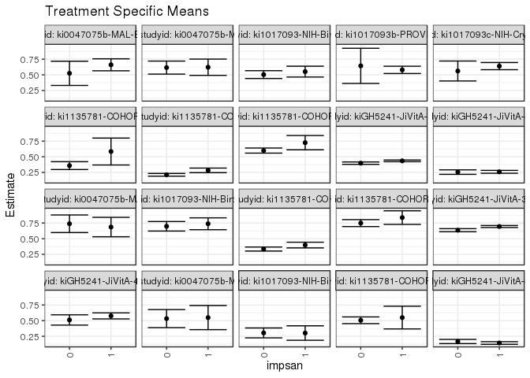

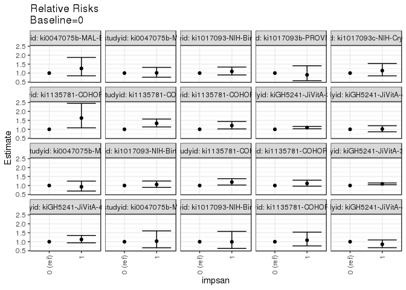

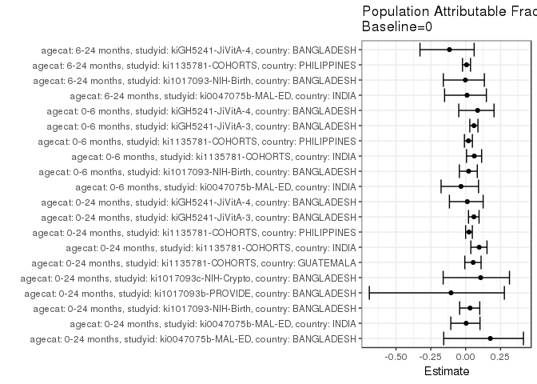

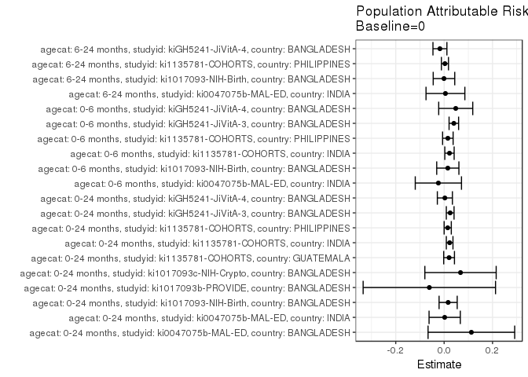

## Results Table

### Parameter: TSM

| agecat | studyid | country | intervention_level | baseline_level | estimate | ci_lower | ci_upper |
| --- | --- | --- | --- | --- | --- | --- | --- |
| 0-24 months | ki0047075b-MAL-ED | BANGLADESH | 0 | NA | 0.5238095 | 0.3303014 | 0.7173177 |
| 0-24 months | ki0047075b-MAL-ED | BANGLADESH | 1 | NA | 0.6600000 | 0.5642467 | 0.7557533 |
| 0-24 months | ki0047075b-MAL-ED | INDIA | 0 | NA | 0.6153846 | 0.5116273 | 0.7191420 |
| 0-24 months | ki0047075b-MAL-ED | INDIA | 1 | NA | 0.6212121 | 0.4912415 | 0.7511827 |
| 0-24 months | ki1017093-NIH-Birth | BANGLADESH | 0 | NA | 0.5036496 | 0.4414527 | 0.5658466 |
| 0-24 months | ki1017093-NIH-Birth | BANGLADESH | 1 | NA | 0.5510204 | 0.4645738 | 0.6374670 |
| 0-24 months | ki1017093b-PROVIDE | BANGLADESH | 0 | NA | 0.6428571 | 0.3621822 | 0.9235321 |
| 0-24 months | ki1017093b-PROVIDE | BANGLADESH | 1 | NA | 0.5787671 | 0.5206376 | 0.6368967 |
| 0-24 months | ki1017093c-NIH-Crypto | BANGLADESH | 0 | NA | 0.5609756 | 0.4015592 | 0.7203920 |
| 0-24 months | ki1017093c-NIH-Crypto | BANGLADESH | 1 | NA | 0.6390977 | 0.5818061 | 0.6963894 |
| 0-24 months | ki1135781-COHORTS | GUATEMALA | 0 | NA | 0.3583333 | 0.2956074 | 0.4210592 |
| 0-24 months | ki1135781-COHORTS | GUATEMALA | 1 | NA | 0.5833333 | 0.3683989 | 0.7982678 |
| 0-24 months | ki1135781-COHORTS | INDIA | 0 | NA | 0.2117117 | 0.1902035 | 0.2332199 |
| 0-24 months | ki1135781-COHORTS | INDIA | 1 | NA | 0.2825397 | 0.2459315 | 0.3191479 |
| 0-24 months | ki1135781-COHORTS | PHILIPPINES | 0 | NA | 0.5986733 | 0.5582519 | 0.6390947 |
| 0-24 months | ki1135781-COHORTS | PHILIPPINES | 1 | NA | 0.7250000 | 0.6113567 | 0.8386433 |
| 0-24 months | kiGH5241-JiVitA-3 | BANGLADESH | 0 | NA | 0.3976945 | 0.3785148 | 0.4168743 |
| 0-24 months | kiGH5241-JiVitA-3 | BANGLADESH | 1 | NA | 0.4344693 | 0.4208320 | 0.4481067 |
| 0-24 months | kiGH5241-JiVitA-4 | BANGLADESH | 0 | NA | 0.2549372 | 0.2189585 | 0.2909158 |
| 0-24 months | kiGH5241-JiVitA-4 | BANGLADESH | 1 | NA | 0.2591362 | 0.2362124 | 0.2820601 |
| 0-6 months | ki0047075b-MAL-ED | INDIA | 0 | NA | 0.7380952 | 0.5974754 | 0.8787151 |
| 0-6 months | ki0047075b-MAL-ED | INDIA | 1 | NA | 0.6857143 | 0.5305267 | 0.8409019 |
| 0-6 months | ki1017093-NIH-Birth | BANGLADESH | 0 | NA | 0.6978417 | 0.6216977 | 0.7739857 |
| 0-6 months | ki1017093-NIH-Birth | BANGLADESH | 1 | NA | 0.7380952 | 0.6434348 | 0.8327557 |
| 0-6 months | ki1135781-COHORTS | INDIA | 0 | NA | 0.3345196 | 0.3026570 | 0.3663822 |
| 0-6 months | ki1135781-COHORTS | INDIA | 1 | NA | 0.3982103 | 0.3528118 | 0.4436088 |
| 0-6 months | ki1135781-COHORTS | PHILIPPINES | 0 | NA | 0.7489177 | 0.6935154 | 0.8043201 |
| 0-6 months | ki1135781-COHORTS | PHILIPPINES | 1 | NA | 0.8367347 | 0.7280039 | 0.9454655 |
| 0-6 months | kiGH5241-JiVitA-3 | BANGLADESH | 0 | NA | 0.6355263 | 0.6113185 | 0.6597341 |
| 0-6 months | kiGH5241-JiVitA-3 | BANGLADESH | 1 | NA | 0.6945828 | 0.6786587 | 0.7105069 |
| 0-6 months | kiGH5241-JiVitA-4 | BANGLADESH | 0 | NA | 0.5104895 | 0.4284825 | 0.5924965 |
| 0-6 months | kiGH5241-JiVitA-4 | BANGLADESH | 1 | NA | 0.5753086 | 0.5271245 | 0.6234928 |
| 6-24 months | ki0047075b-MAL-ED | INDIA | 0 | NA | 0.5322581 | 0.3882846 | 0.6762315 |
| 6-24 months | ki0047075b-MAL-ED | INDIA | 1 | NA | 0.5483871 | 0.3554241 | 0.7413501 |
| 6-24 months | ki1017093-NIH-Birth | BANGLADESH | 0 | NA | 0.3037037 | 0.2246718 | 0.3827357 |
| 6-24 months | ki1017093-NIH-Birth | BANGLADESH | 1 | NA | 0.3015873 | 0.1861854 | 0.4169892 |
| 6-24 months | ki1135781-COHORTS | PHILIPPINES | 0 | NA | 0.5053763 | 0.4516690 | 0.5590836 |
| 6-24 months | ki1135781-COHORTS | PHILIPPINES | 1 | NA | 0.5483871 | 0.3670161 | 0.7297581 |
| 6-24 months | kiGH5241-JiVitA-4 | BANGLADESH | 0 | NA | 0.1666667 | 0.1328485 | 0.2004848 |
| 6-24 months | kiGH5241-JiVitA-4 | BANGLADESH | 1 | NA | 0.1427273 | 0.1220970 | 0.1633575 |

### Parameter: E(Y)

| agecat | studyid | country | intervention_level | baseline_level | estimate | ci_lower | ci_upper |
| --- | --- | --- | --- | --- | --- | --- | --- |
| 0-24 months | ki0047075b-MAL-ED | BANGLADESH | NA | NA | 0.6363636 | 0.5494154 | 0.7233119 |
| 0-24 months | ki0047075b-MAL-ED | INDIA | NA | NA | 0.6176471 | 0.5365376 | 0.6987565 |
| 0-24 months | ki1017093-NIH-Birth | BANGLADESH | NA | NA | 0.5201900 | 0.4695846 | 0.5707955 |
| 0-24 months | ki1017093b-PROVIDE | BANGLADESH | NA | NA | 0.5816993 | 0.5247676 | 0.6386311 |
| 0-24 months | ki1017093c-NIH-Crypto | BANGLADESH | NA | NA | 0.6286645 | 0.5746609 | 0.6826681 |
| 0-24 months | ki1135781-COHORTS | GUATEMALA | NA | NA | 0.3787879 | 0.3179432 | 0.4396325 |
| 0-24 months | ki1135781-COHORTS | INDIA | NA | NA | 0.2344546 | 0.2156201 | 0.2532892 |
| 0-24 months | ki1135781-COHORTS | PHILIPPINES | NA | NA | 0.6134700 | 0.5751620 | 0.6517779 |
| 0-24 months | kiGH5241-JiVitA-3 | BANGLADESH | NA | NA | 0.4226600 | 0.4115317 | 0.4337883 |
| 0-24 months | kiGH5241-JiVitA-4 | BANGLADESH | NA | NA | 0.2580019 | 0.2386523 | 0.2773515 |
| 0-6 months | ki0047075b-MAL-ED | INDIA | NA | NA | 0.7142857 | 0.6098683 | 0.8187031 |
| 0-6 months | ki1017093-NIH-Birth | BANGLADESH | NA | NA | 0.7130045 | 0.6535890 | 0.7724200 |
| 0-6 months | ki1135781-COHORTS | INDIA | NA | NA | 0.3565891 | 0.3304405 | 0.3827378 |
| 0-6 months | ki1135781-COHORTS | PHILIPPINES | NA | NA | 0.7642857 | 0.7146210 | 0.8139505 |
| 0-6 months | kiGH5241-JiVitA-3 | BANGLADESH | NA | NA | 0.6756128 | 0.6622741 | 0.6889516 |
| 0-6 months | kiGH5241-JiVitA-4 | BANGLADESH | NA | NA | 0.5583942 | 0.5167799 | 0.6000084 |
| 6-24 months | ki0047075b-MAL-ED | INDIA | NA | NA | 0.5376344 | 0.4216441 | 0.6536248 |
| 6-24 months | ki1017093-NIH-Birth | BANGLADESH | NA | NA | 0.3030303 | 0.2377927 | 0.3682679 |
| 6-24 months | ki1135781-COHORTS | PHILIPPINES | NA | NA | 0.5086849 | 0.4571562 | 0.5602135 |
| 6-24 months | kiGH5241-JiVitA-4 | BANGLADESH | NA | NA | 0.1492734 | 0.1316631 | 0.1668838 |

### Parameter: RR

| agecat | studyid | country | intervention_level | baseline_level | estimate | ci_lower | ci_upper |
| --- | --- | --- | --- | --- | --- | --- | --- |
| 0-24 months | ki0047075b-MAL-ED | BANGLADESH | 0 | 0 | 1.0000000 | 1.0000000 | 1.000000 |
| 0-24 months | ki0047075b-MAL-ED | BANGLADESH | 1 | 0 | 1.2600000 | 0.8472149 | 1.873905 |
| 0-24 months | ki0047075b-MAL-ED | INDIA | 0 | 0 | 1.0000000 | 1.0000000 | 1.000000 |
| 0-24 months | ki0047075b-MAL-ED | INDIA | 1 | 0 | 1.0094697 | 0.7716305 | 1.320618 |
| 0-24 months | ki1017093-NIH-Birth | BANGLADESH | 0 | 0 | 1.0000000 | 1.0000000 | 1.000000 |
| 0-24 months | ki1017093-NIH-Birth | BANGLADESH | 1 | 0 | 1.0940550 | 0.8959643 | 1.335942 |
| 0-24 months | ki1017093b-PROVIDE | BANGLADESH | 0 | 0 | 1.0000000 | 1.0000000 | 1.000000 |
| 0-24 months | ki1017093b-PROVIDE | BANGLADESH | 1 | 0 | 0.9003044 | 0.5752332 | 1.409077 |
| 0-24 months | ki1017093c-NIH-Crypto | BANGLADESH | 0 | 0 | 1.0000000 | 1.0000000 | 1.000000 |
| 0-24 months | ki1017093c-NIH-Crypto | BANGLADESH | 1 | 0 | 1.1392612 | 0.8454022 | 1.535265 |
| 0-24 months | ki1135781-COHORTS | GUATEMALA | 0 | 0 | 1.0000000 | 1.0000000 | 1.000000 |
| 0-24 months | ki1135781-COHORTS | GUATEMALA | 1 | 0 | 1.6279070 | 1.0825921 | 2.447904 |
| 0-24 months | ki1135781-COHORTS | INDIA | 0 | 0 | 1.0000000 | 1.0000000 | 1.000000 |
| 0-24 months | ki1135781-COHORTS | INDIA | 1 | 0 | 1.3345491 | 1.1319671 | 1.573386 |
| 0-24 months | ki1135781-COHORTS | PHILIPPINES | 0 | 0 | 1.0000000 | 1.0000000 | 1.000000 |
| 0-24 months | ki1135781-COHORTS | PHILIPPINES | 1 | 0 | 1.2110111 | 1.0209783 | 1.436414 |
| 0-24 months | kiGH5241-JiVitA-3 | BANGLADESH | 0 | 0 | 1.0000000 | 1.0000000 | 1.000000 |
| 0-24 months | kiGH5241-JiVitA-3 | BANGLADESH | 1 | 0 | 1.0924700 | 1.0313810 | 1.157177 |
| 0-24 months | kiGH5241-JiVitA-4 | BANGLADESH | 0 | 0 | 1.0000000 | 1.0000000 | 1.000000 |
| 0-24 months | kiGH5241-JiVitA-4 | BANGLADESH | 1 | 0 | 1.0164709 | 0.8605068 | 1.200703 |
| 0-6 months | ki0047075b-MAL-ED | INDIA | 0 | 0 | 1.0000000 | 1.0000000 | 1.000000 |
| 0-6 months | ki0047075b-MAL-ED | INDIA | 1 | 0 | 0.9290323 | 0.6910984 | 1.248883 |
| 0-6 months | ki1017093-NIH-Birth | BANGLADESH | 0 | 0 | 1.0000000 | 1.0000000 | 1.000000 |
| 0-6 months | ki1017093-NIH-Birth | BANGLADESH | 1 | 0 | 1.0576829 | 0.8937715 | 1.251654 |
| 0-6 months | ki1135781-COHORTS | INDIA | 0 | 0 | 1.0000000 | 1.0000000 | 1.000000 |
| 0-6 months | ki1135781-COHORTS | INDIA | 1 | 0 | 1.1903946 | 1.0260596 | 1.381050 |
| 0-6 months | ki1135781-COHORTS | PHILIPPINES | 0 | 0 | 1.0000000 | 1.0000000 | 1.000000 |
| 0-6 months | ki1135781-COHORTS | PHILIPPINES | 1 | 0 | 1.1172585 | 0.9620873 | 1.297457 |
| 0-6 months | kiGH5241-JiVitA-3 | BANGLADESH | 0 | 0 | 1.0000000 | 1.0000000 | 1.000000 |
| 0-6 months | kiGH5241-JiVitA-3 | BANGLADESH | 1 | 0 | 1.0929253 | 1.0454001 | 1.142611 |
| 0-6 months | kiGH5241-JiVitA-4 | BANGLADESH | 0 | 0 | 1.0000000 | 1.0000000 | 1.000000 |
| 0-6 months | kiGH5241-JiVitA-4 | BANGLADESH | 1 | 0 | 1.1269745 | 0.9402312 | 1.350808 |
| 6-24 months | ki0047075b-MAL-ED | INDIA | 0 | 0 | 1.0000000 | 1.0000000 | 1.000000 |
| 6-24 months | ki0047075b-MAL-ED | INDIA | 1 | 0 | 1.0303030 | 0.6616741 | 1.604301 |
| 6-24 months | ki1017093-NIH-Birth | BANGLADESH | 0 | 0 | 1.0000000 | 1.0000000 | 1.000000 |
| 6-24 months | ki1017093-NIH-Birth | BANGLADESH | 1 | 0 | 0.9930314 | 0.6253409 | 1.576918 |
| 6-24 months | ki1135781-COHORTS | PHILIPPINES | 0 | 0 | 1.0000000 | 1.0000000 | 1.000000 |
| 6-24 months | ki1135781-COHORTS | PHILIPPINES | 1 | 0 | 1.0851064 | 0.7666660 | 1.535813 |
| 6-24 months | kiGH5241-JiVitA-4 | BANGLADESH | 0 | 0 | 1.0000000 | 1.0000000 | 1.000000 |
| 6-24 months | kiGH5241-JiVitA-4 | BANGLADESH | 1 | 0 | 0.8563636 | 0.6674867 | 1.098686 |

### Parameter: PAR

| agecat | studyid | country | intervention_level | baseline_level | estimate | ci_lower | ci_upper |
| --- | --- | --- | --- | --- | --- | --- | --- |
| 0-24 months | ki0047075b-MAL-ED | BANGLADESH | 0 | NA | 0.1125541 | -0.0664151 | 0.2915233 |
| 0-24 months | ki0047075b-MAL-ED | INDIA | 0 | NA | 0.0022624 | -0.0623051 | 0.0668299 |
| 0-24 months | ki1017093-NIH-Birth | BANGLADESH | 0 | NA | 0.0165404 | -0.0209030 | 0.0539838 |
| 0-24 months | ki1017093b-PROVIDE | BANGLADESH | 0 | NA | -0.0611578 | -0.3347113 | 0.2123957 |
| 0-24 months | ki1017093c-NIH-Crypto | BANGLADESH | 0 | NA | 0.0676889 | -0.0796949 | 0.2150727 |
| 0-24 months | ki1135781-COHORTS | GUATEMALA | 0 | NA | 0.0204545 | -0.0017450 | 0.0426541 |
| 0-24 months | ki1135781-COHORTS | INDIA | 0 | NA | 0.0227429 | 0.0090172 | 0.0364687 |
| 0-24 months | ki1135781-COHORTS | PHILIPPINES | 0 | NA | 0.0147967 | -0.0000027 | 0.0295961 |
| 0-24 months | kiGH5241-JiVitA-3 | BANGLADESH | 0 | NA | 0.0249654 | 0.0089868 | 0.0409441 |
| 0-24 months | kiGH5241-JiVitA-4 | BANGLADESH | 0 | NA | 0.0030648 | -0.0280718 | 0.0342013 |
| 0-6 months | ki0047075b-MAL-ED | INDIA | 0 | NA | -0.0238095 | -0.1193383 | 0.0717192 |
| 0-6 months | ki1017093-NIH-Birth | BANGLADESH | 0 | NA | 0.0151628 | -0.0306737 | 0.0609992 |
| 0-6 months | ki1135781-COHORTS | INDIA | 0 | NA | 0.0220696 | 0.0027796 | 0.0413596 |
| 0-6 months | ki1135781-COHORTS | PHILIPPINES | 0 | NA | 0.0153680 | -0.0063811 | 0.0371170 |
| 0-6 months | kiGH5241-JiVitA-3 | BANGLADESH | 0 | NA | 0.0400865 | 0.0204025 | 0.0597706 |
| 0-6 months | kiGH5241-JiVitA-4 | BANGLADESH | 0 | NA | 0.0479047 | -0.0224307 | 0.1182400 |
| 6-24 months | ki0047075b-MAL-ED | INDIA | 0 | NA | 0.0053763 | -0.0748525 | 0.0856052 |
| 6-24 months | ki1017093-NIH-Birth | BANGLADESH | 0 | NA | -0.0006734 | -0.0451526 | 0.0438058 |
| 6-24 months | ki1135781-COHORTS | PHILIPPINES | 0 | NA | 0.0033085 | -0.0113101 | 0.0179271 |
| 6-24 months | kiGH5241-JiVitA-4 | BANGLADESH | 0 | NA | -0.0173932 | -0.0462087 | 0.0114223 |

### Parameter: PAF

| agecat | studyid | country | intervention_level | baseline_level | estimate | ci_lower | ci_upper |
| --- | --- | --- | --- | --- | --- | --- | --- |
| 0-24 months | ki0047075b-MAL-ED | BANGLADESH | 0 | NA | 0.1768707 | -0.1575016 | 0.4146515 |
| 0-24 months | ki0047075b-MAL-ED | INDIA | 0 | NA | 0.0036630 | -0.1065581 | 0.1029053 |
| 0-24 months | ki1017093-NIH-Birth | BANGLADESH | 0 | NA | 0.0317968 | -0.0429151 | 0.1011566 |
| 0-24 months | ki1017093b-PROVIDE | BANGLADESH | 0 | NA | -0.1051364 | -0.6911138 | 0.2777975 |
| 0-24 months | ki1017093c-NIH-Crypto | BANGLADESH | 0 | NA | 0.1076709 | -0.1612716 | 0.3143282 |
| 0-24 months | ki1135781-COHORTS | GUATEMALA | 0 | NA | 0.0540000 | -0.0062535 | 0.1106456 |
| 0-24 months | ki1135781-COHORTS | INDIA | 0 | NA | 0.0970035 | 0.0372666 | 0.1530338 |
| 0-24 months | ki1135781-COHORTS | PHILIPPINES | 0 | NA | 0.0241197 | -0.0002816 | 0.0479256 |
| 0-24 months | kiGH5241-JiVitA-3 | BANGLADESH | 0 | NA | 0.0590674 | 0.0205109 | 0.0961062 |
| 0-24 months | kiGH5241-JiVitA-4 | BANGLADESH | 0 | NA | 0.0118789 | -0.1164462 | 0.1254542 |
| 0-6 months | ki0047075b-MAL-ED | INDIA | 0 | NA | -0.0333333 | -0.1762859 | 0.0922464 |
| 0-6 months | ki1017093-NIH-Birth | BANGLADESH | 0 | NA | 0.0212660 | -0.0452626 | 0.0835602 |
| 0-6 months | ki1135781-COHORTS | INDIA | 0 | NA | 0.0618908 | 0.0061968 | 0.1144636 |
| 0-6 months | ki1135781-COHORTS | PHILIPPINES | 0 | NA | 0.0201076 | -0.0088778 | 0.0482603 |
| 0-6 months | kiGH5241-JiVitA-3 | BANGLADESH | 0 | NA | 0.0593336 | 0.0296709 | 0.0880895 |
| 0-6 months | kiGH5241-JiVitA-4 | BANGLADESH | 0 | NA | 0.0857900 | -0.0495042 | 0.2036431 |
| 6-24 months | ki0047075b-MAL-ED | INDIA | 0 | NA | 0.0100000 | -0.1511904 | 0.1486204 |
| 6-24 months | ki1017093-NIH-Birth | BANGLADESH | 0 | NA | -0.0022222 | -0.1602965 | 0.1343166 |
| 6-24 months | ki1135781-COHORTS | PHILIPPINES | 0 | NA | 0.0065041 | -0.0226684 | 0.0348444 |
| 6-24 months | kiGH5241-JiVitA-4 | BANGLADESH | 0 | NA | -0.1165192 | -0.3277793 | 0.0611278 |